# Projet R

Bill Yehouenou, Aymard Loic Kwekeu Kwekeu, Omar Saip Sy

2022-10-30

# Partie 1 : Prise en main des données

## 1. Cancero

```r
cancero <- read.table("data/CANCERO_2019.csv", header=TRUE, sep=";", dec="." )

nb_adultMCO <- sum(cancero$CANCERO_A11, na.rm = TRUE) #nombre adultes en MCO
print(paste("Le nombre d'adultes ayant eu un traitement par chimiothérapie dans l'année en MCO", nb_adultMCO))
```

```
[1] "Le nombre d'adultes ayant eu un traitement par chimiothérapie dans l'année en MCO 356899"
```

```r
nb_adult_HAD_MCO <- nb_adultMCO + sum(cancero$CANCERO_B11, na.rm= TRUE)
nb_enfant_HAD_MCO <- sum(cancero$CANCERO_C11,na.rm=TRUE) + sum(cancero$CANCERO_D11, na.rm=TRUE)
prop_had_mco <- prop.table(cbind(nb_adult_HAD_MCO,nb_enfant_HAD_MCO)) #proportion d'adultes et d'enfants

plus_grande_valeur <- function(x,y){
  if(x > y){
    return("Il y a plus de patiens adultes atteints de cancer ayant un traitement de cancer que de jeunes dans la même situation")
  } else {
    return("Il y a plus de patiens jeunes atteints de cancer ayant un traitement de cancer que d'adultes dans la même situation")
  }
}
plus_grande_valeur(prop_had_mco[,1],prop_had_mco[,2])
```

```
[1] "Il y a plus de patiens adultes atteints de cancer ayant un traitement de cancer que de jeunes dans la même situation"
```

Ce résultat est normal car les jeunes de moins de 18 ans développent moins de cancer que les adultes.

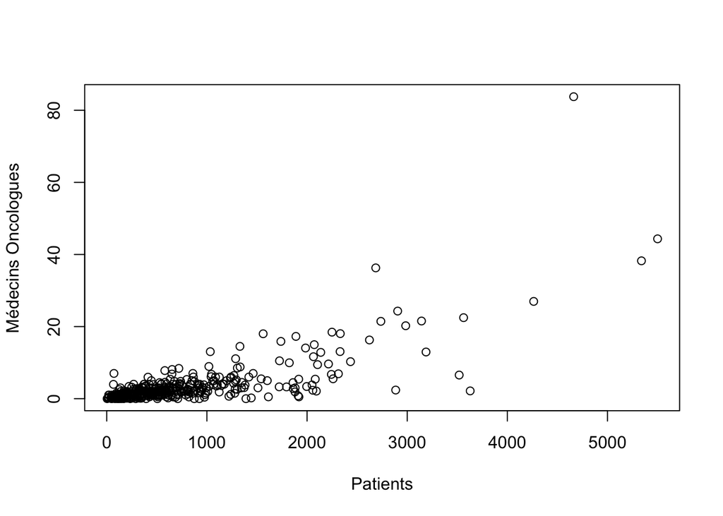

```r
Patients <- cancero$CANCERO_A11+cancero$CANCERO_B11+cancero$CANCERO_C11+cancero$CANCERO_D11
cancero <- cbind(cancero, Patients)

plot(Patients, cancero$CANCERO_C28,ylab = "Médecins Oncologues")
```

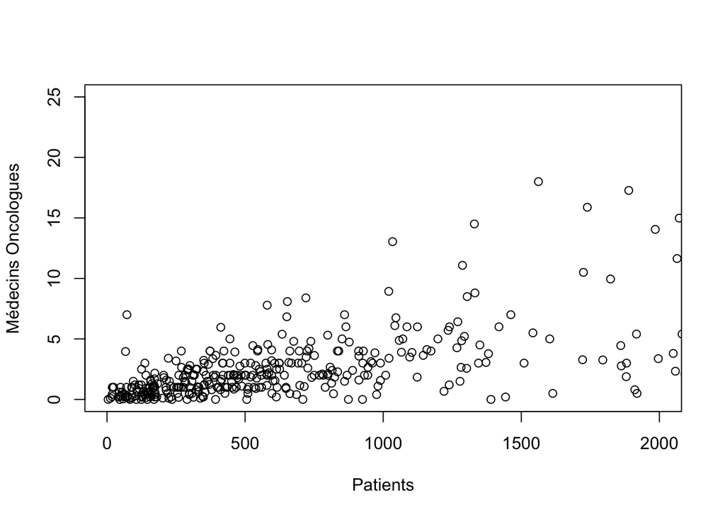

```r
#Zoom sur un graphique
plot(Patients, cancero$CANCERO_C28, xlim=c(0,2000),ylim=c(0,25), ylab="Médecins Oncologues" )
```

L’analyse de ce graphe montre une augmentation du **nombre de médecins oncologues** avec la croissance du nombre de Patients atteints du cancer dans les hôpitaux. On remarque aussi une forte présence des hôpitaux avec moins de 20 oncologues.

## 2. Urgences

```r
urgences_2019 <- read.csv("data/URGENCES2_2019.csv", sep = ";")
```

```r
attach(urgences_2019)
urgences_gen_80 <- urgences_2019[c(URG == "GEN"),"dt80"]
urgences_gen_18 <- urgences_2019[c(URG == "GEN"),"dt18"]
if (sum(na.omit(urgences_gen_80))>sum(urgences_gen_18, na.rm = TRUE)){
  print("Les patients de +80 ans sont plus nombreux aux urgences générales que ceux de -18 ans en 2019")
} else {
  print("Les patients de -18 ans sont plus nombreux aux urgences générales que ceux de +80 ans en 2019")
}
```

```
[1] "Les patients de -18 ans sont plus nombreux aux urgences générales que ceux de +80 ans en 2019"
```

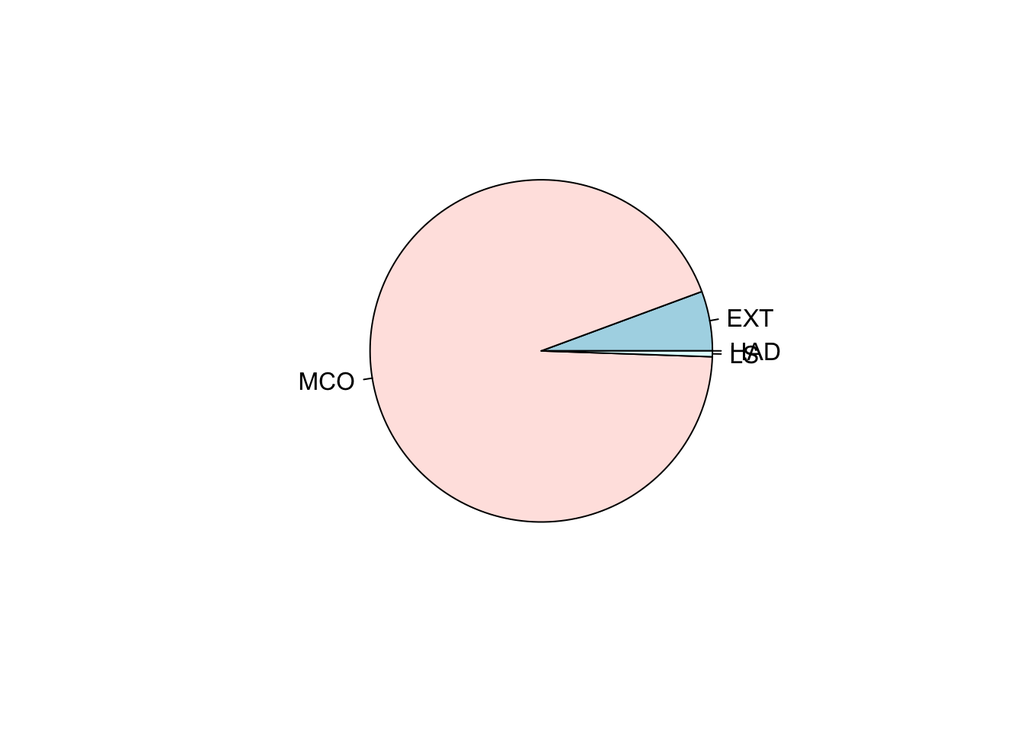

```r
#étude unité urgence générale -18 ans
urgences_gen_18unit <- urgences_2019[c(URG == "GEN"),c("dtHAD18", "dtEXT18", "dtMCO18", "dtLS18")]
somme_unit18 <- colSums(na.omit(urgences_gen_18unit))
pie(somme_unit18, labels = c("HAD","EXT","MCO","LS"))
```

On remarque que l’unité d’urgence générale de “Médecine, chirurgie et obstétrique” reçoit beaucoup de patients en bas âge que toutes les autres unités spéciales d’urgences générales. Cela se traduit par une forte proportion de patients âgés de moins de 18 ans (environ **93.81%**).

```r
urgences_2020 <- read.csv("data/URGENCES2_2019.csv", sep = ";")
urgences_gen_lit19 <- urgences_2019[c(urgences_2019$URG == "GEN"),"LIT_UHCD"]
urgences_gen_lit20 <- urgences_2020[c(urgences_2020$URG == "GEN"),"LIT_UHCD"]

lit_rajoute = 0
for (ligne in 1:nrow(urgences_2019)) {
  if (is.na(urgences_gen_lit19[ligne]) && is.na(urgences_gen_lit20[ligne])){next}
  else if ((urgences_gen_lit19[ligne] < urgences_gen_lit20[ligne]) || (is.na(urgences_gen_lit19[ligne]) &&  !is.na(urgences_gen_lit20[ligne]))) {
    lit_rajoute <- lit_rajoute + 1}
}
print(lit_rajoute)
```

```
[1] 0
```

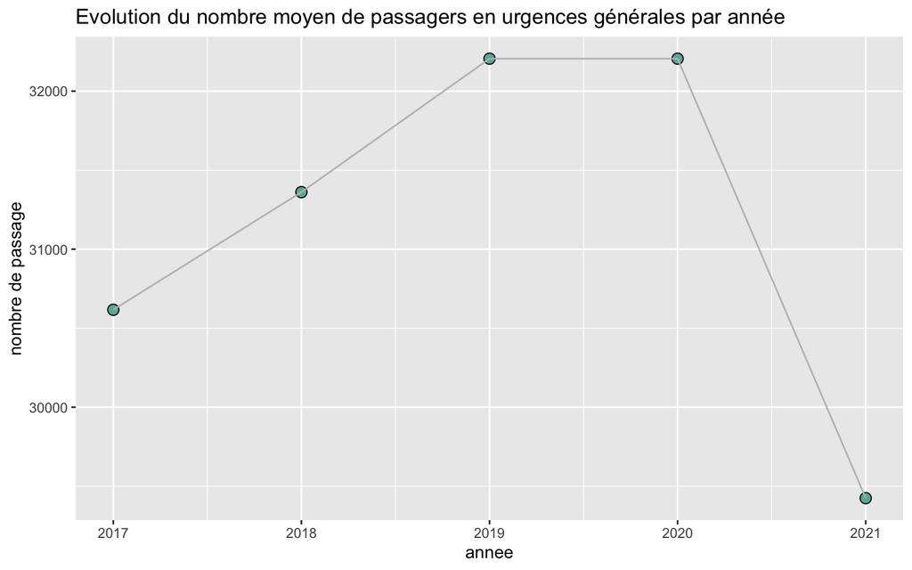

```r
#importation des autres données
urgences_2017 <- read.csv("data/URGENCES2_2017.csv", sep = ";")
urgences_2018 <- read.csv("data/URGENCES2_2018.csv", sep = ";")
urgences_2021 <- read.csv("data/URGENCES2_2021.csv", sep = ";")
#Extraction du nombre de passagers en urgences par année
urgences_gen_passu17 <- na.omit(urgences_2017[c(urgences_2017$URG == "GEN"), "PASSU"])
urgences_gen_passu18 <- na.omit(urgences_2018[c(urgences_2018$URG == "GEN"), "PASSU"])
urgences_gen_passu19 <- na.omit(urgences_2019[c(urgences_2019$URG == "GEN"), "PASSU"])
urgences_gen_passu20 <- na.omit(urgences_2020[c(urgences_2020$URG == "GEN"), "PASSU"])
urgences_gen_passu21 <- na.omit(urgences_2021[c(urgences_2020$URG == "GEN"), "PASSU"])
urgences_gen_passu <- cbind(urgences_gen_passu17,urgences_gen_passu18,urgences_gen_passu19,urgences_gen_passu20, urgences_gen_passu21)
annee <- 2017:2021
gen_passu <- data.frame(annee, passu = colMeans(urgences_gen_passu))
#Représentation graphique
ggplot(gen_passu, aes(x=annee, y=passu)) +
  geom_point(shape=21, color="black", fill="#69b3a2", size=3) +
  geom_line(color="grey") +
  ylab("nombre de passage") +
  ggtitle("Evolution du nombre moyen de passagers en urgences générales par année")
```

## 3. Q20

```r
q20 <- read.table("data/Q20_2019.csv", header = TRUE, sep = ";")
nb_NA = c()
for (colonne in 6:ncol(q20)){
  somme = 0
  for (ligne in 1:nrow(q20)){
    if(is.na(q20[ligne,colonne])){
      somme <- somme+1
    }
  }
  nb_NA <- c(nb_NA, somme)
}
prop_NA <- data.frame(variables = variable.names(q20)[6:ncol(q20)],
                           pourcentage_vide = (nb_NA/nrow(q20))*100)
prop_NA #pourcentage de valeurs manquantes
```

```
   variables pourcentage_vide
1  EFFSALPLH         54.36202
2  EFFSALPLF         55.50356
3  EFFSALPAH         57.36342
4  EFFSALPAF         55.95362
5  EFFLIBPLH         75.74737
6  EFFLIBPLF         81.14512
7  EFFLIBPAH         68.08143
8  EFFLIBPAF         76.57000
9    ETPSALH         39.07186
10   ETPSALF         40.16274
11    ETP_PU         82.65029
12    ETP_PH         59.17856
13    ETP_AS         78.11690
14    ETP_HU         83.52061
15    ETP_AT         70.14992
16    ETP_AU         68.44207
17    EFFSAL         28.38365
18    ETPSAL         25.67733
19    EFFLIB         57.27698
```

Le tableau ci-dessus est un tableau de chaque variable et de son pourcentage de données manquantes. Nous observons que la variable avec le plus faible pourcentage de données manquantes est ETPSAL (ETP moyen annuel rémunéré total). La variable avec le plus fort pourcentage de données manquantes est ETP_HU (Etablissement public dont ETP des hospitaliers universitaires non titulaires).

```r
gp_H_par_spe <- aggregate(EFFSALPLH ~ PERSO, sum, data = q20)
gp_F_par_spe <- aggregate(EFFSALPLF ~ PERSO, sum, data = q20)

tab_hf <- data.frame(gp_F_par_spe$EFFSALPLF, gp_H_par_spe$EFFSALPLH)

pourcentage_homme <- (gp_H_par_spe$EFFSALPLH / rowSums(tab_hf))*100
prop_h_tp <- data.frame(id_spe = gp_H_par_spe$PERSO, pourcentage_homme)
prop_h_tp #proprtion d'hommes salariés à temps plein
```

```
   id_spe pourcentage_homme
1   M1010          51.48813
2   M1020          36.18421
3   M1030          57.99645
4   M1031          70.32787
5   M1040          67.92453
6   M1050          28.82562
7   M1070          28.28947
8   M1090          52.66749
9   M1100          50.33073
10  M1110          54.65414
11  M1120          47.55245
12  M1130          42.98507
13  M1140          32.68629
14  M1150          52.96143
```

[output cut: 33 more lines]

Le tableau ci-dessus est le tableau qui associé à chaque identifiant de spécialité le pourcentage d’homme qu’il y a parmi les salariés à temps plein. Nous pouvons observer que parmi tous les personnels salariés à temps plein, il y a environ 50.8% d’hommes ; ce qui est proche de 50%. De ce fait, il y a autant d’hommes que de femmes faisant partie du personnel médical total. La proportion d’hommes salarié à temps plein varie entre 28.3% et 89.7% en fonction des spécialités. En effet, ces faibles proportions s’expliquent par le fait que certaines spécialités de la médecine sont plus abordables par les femmes que par les hommes; nous avons l’exemple de la gynécologie et de l’obstétrique. Les fortes proportions se justifient du fait d’autres spécialistes de la médecine sont plus praticables par les hommes; nous avons l’exemple de l’urologie.

```r
desc_perso <- read.csv("data/Desc_Perso.csv",sep=",") #importation

for(spe in gp_H_par_spe$PERSO){
  for(specialite in desc_perso$Valeur.Modalité){
    if(spe == specialite){
      gp_H_par_spe$PERSO[which(gp_H_par_spe$PERSO == spe)] = desc_perso$Label.modalité[which(desc_perso$Valeur.Modalité == specialite)]
      #affecter chaque id_spe au nom de la spécialité correspondante pour le tableau groupée des hommes
      prop_h_tp$id_spe[which(prop_h_tp$id_spe == spe)] = desc_perso$Label.modalité[which(desc_perso$Valeur.Modalité == specialite)]
      ##affecter chaque id_spe au nom de la spécialité correspondante pour la proportion des hommes
      }
  }
}

maxi = prop_h_tp[which.max(prop_h_tp$pourcentage_homme),1] #Spécilalité avec le plus d'hommes à temps plein
mini = prop_h_tp[which.min(prop_h_tp$pourcentage_homme),1] #Spécilalité avec le moins d'hommes à temps plein

comparaison= c ()
for(pourcentage in prop_h_tp$pourcentage_homme){
  comparaison=c(comparaison, abs(pourcentage-50)) #distance entre le pourcentage et 1/2
}
idx <- which.min(comparaison)
proche <- prop_h_tp[idx,1]
print(paste("La spécialité avec la plus grande proportion est :", maxi,
            ",celle avec la plus petite proportion est :", mini,
            "et celle avec la proportion la plus proche de 50% est :", proche))
```

```
[1] "La spécialité avec la plus grande proportion est : Chirurgie orthopédique et traumatologique ,celle avec la plus petite proportion est : Endocrinologie et maladies métaboliques et celle avec la proportion la plus proche de 50% est : Médecine physique et de réadaptation"
```

```r
etp_pu <- aggregate(ETP_PU ~ PERSO, sum, data = q20)

for (spe in etp_pu$PERSO){
  for (specialite in desc_perso$Valeur.Modalité){
    if (spe == specialite){
      etp_pu$PERSO[which(etp_pu$PERSO==spe)] = desc_perso$Label.modalité[which(desc_perso$Valeur.Modalité == specialite)]
    }
  }
}
etp_pu_ordonne <- etp_pu[order(etp_pu$ETP_PU,decreasing = F),]
etp_pu_ordonne[1:10,]
```

```
                                                         PERSO ETP_PU
34                            Autres spécialités chirurgicales   8.43
16                                   Oncologie radiothérapique  13.08
45                                         Médecins du travail  14.11
26 Chirurgie maxillo-faciale  - Stomatologie - Chirurgie orale  20.12
22                                                   Gériatrie  20.81
28          Chirurgie plastique, reconstructrice et esthétique  22.17
38                                         Chirurgie infantile  23.83
24                                          Médecine d'urgence  24.63
36                                        Chirurgie vasculaire  28.03
17                        Médecine physique et de réadaptation  29.05
```

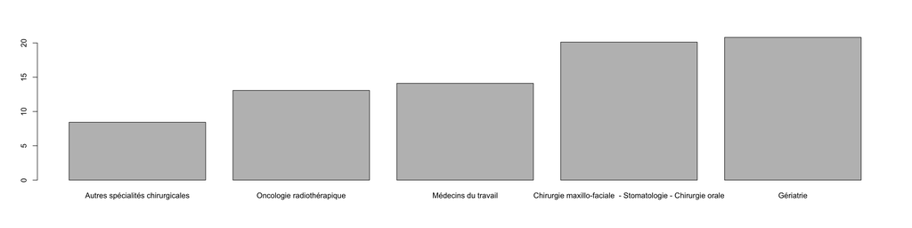

```r
#Diagramme en bâtons
barplot(height = etp_pu_ordonne[1:5,2], axisnames = TRUE, names.arg = etp_pu_ordonne[1:5,1])
```

# Partie 2 : Description et analyse des données

## Problématique

**Existe-il une relation entre la présence d’équipement et le nombre de patients par année dans un hôpital ?** Notre étude a pour objectif de vérifier si un établissement de santé plus équipé attire plus de patients que ceux qui le sont moins. On a donc décider d’axer notre étude sur le département “Radiothérapie” dans la base Cancero. En effet, ce choix se justifie par le constat que les individus atteints de pathologie assez particulières, dont les soins requièrent des équipements de pointe, accordent plus d’importance au choix des établissements de santé.

## Méthodologie utilisée

Pour mener à bien notre étude, nous avons décider d’utiliser un modèle de **regression linéaire multiple** par la méthode des moindres carrées ordinaires (MCO). Cette méthode sert modéliser la valeur d’une variable en fonction de la valeur d’une ou plusieurs autres variables. Notre **variable d’état** ou **d’intérêt** est “le nombre de patients”. Celle-ci sera modélisée en fonction de plusieurs **variables explicatives** : - *nombre d’appareils (ou de lits)* - *séances de traitement par radiothérapie externe* - *nombre de médecins radiothérapeutes (hors internes)*

## Creation de la base de données

```r
nb_patients <- cancero$CANCERO_A17+cancero$CANCERO_B17
nb_appareils <- cancero$CANCERO_A12
traitement <- cancero$CANCERO_A15+cancero$CANCERO_B15
radiotherap <- cancero$CANCERO_A19+cancero$CANCERO_B19

cancero_radio<-data.frame(nb_patients, nb_appareils, traitement, radiotherap)
```

## Analyse descriptive

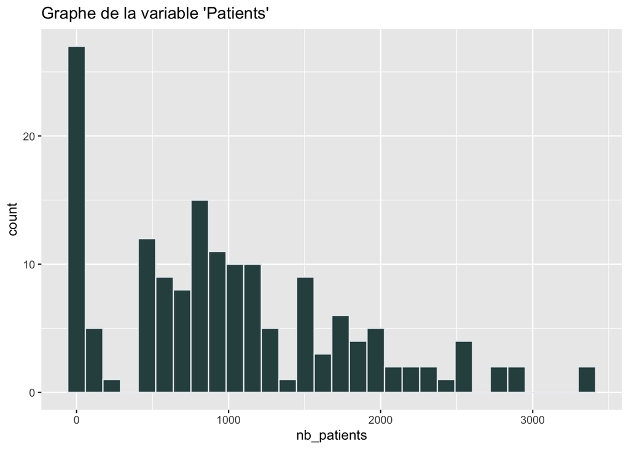

```r
#Graphe de la variable 'nb_patients'
ggplot(cancero_radio, aes(x=nb_patients)) +
  geom_histogram(fill="darkslategray", color = "#e9ecef") +
    ggtitle("Graphe de la variable 'Patients'")
```

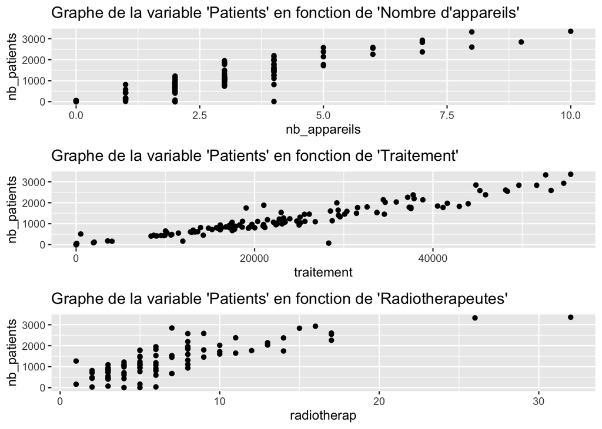

```r
# Graphe de la variable 'nb_appareils'
graph_app <- ggplot(cancero_radio) +
  geom_point(aes(x=nb_appareils,y=nb_patients)) +
    ggtitle("Graphe de la variable 'Patients' en fonction de 'Nombre d'appareils'")
# Graphe de la variable 'traitement'
graph_trait <- ggplot(cancero_radio) +
  geom_point(aes(x=traitement,y=nb_patients)) +
    ggtitle("Graphe de la variable 'Patients' en fonction de 'Traitement'")
# Graphe de la variable 'radiotherap'
graph_radthp <- ggplot(cancero_radio) +
  geom_point(aes(x=radiotherap,y=nb_patients)) +
    ggtitle("Graphe de la variable 'Patients' en fonction de 'Radiotherapeutes'")

plot_grid(graph_app,graph_trait,graph_radthp ,nrow = 3) #tous les graphes dans une meme grille (library_cowplot)
```

## Mise en oeuvre de la méthode

```r
reg<-lm(nb_patients~nb_appareils+traitement+radiotherap,data=cancero_radio)
summary(reg)
```

```
Call:
lm(formula = nb_patients ~ nb_appareils + traitement + radiotherap,
    data = cancero_radio)

Residuals:
     Min       1Q   Median       3Q      Max
-1072.91   -75.79    -0.03    74.49   760.78

Coefficients:
               Estimate Std. Error t value Pr(>|t|)
(Intercept)  -1.581e+02  4.629e+01  -3.415 0.000991 ***
nb_appareils  1.255e+02  2.588e+01   4.847 5.75e-06 ***
traitement    3.505e-02  2.942e-03  11.916  < 2e-16 ***
radiotherap   2.056e+01  7.357e+00   2.795 0.006442 **
---
Signif. codes:  0 '***' 0.001 '**' 0.01 '*' 0.05 '.' 0.1 ' ' 1

Residual standard error: 203.8 on 83 degrees of freedom
  (900 observations deleted due to missingness)
Multiple R-squared:  0.937, Adjusted R-squared:  0.9347
F-statistic: 411.5 on 3 and 83 DF,  p-value: < 2.2e-16
```

### **Commentaires de chacun des modèles**

- Qualité d’ajustement du modèle $ R^2_a = 0.9347 $, donc 93,47 % de la variance du nombre de patients est expliquée par *nombre d’appareils (ou de lits)*, *séances de traitement par radiothérapie externe*, *nombre de médecins radiothérapeutes (hors internes)*.
- Test de Fisher global (test de significativité globale du modèle) Le modèle est **globalement satisfaisant** car F-statistic est < 5%
- Les coefficients de toutes les variables sont significatifs au seuil de 5% car leurs *p-values* respectives sont inférieures à 5%.

Ainsi, si on rajoute un appareil en plus, le nombre de patients devrait augmenter de 125 personnes. De plus, si le nombre de séances de traitement par radiothérapie externe de 100 alors on gagne environ 4 patients en plus. Enfin, si on engage un radiothérapeute en plus, le nombre de patients pourrait augmenter de 20 personnes.